# GroundState_Affymetrix_analysis.Rmd

Hilmar Berger

04 November, 2020 12:11:37

```r
rm(list=ls())
library(data.table)
library(reshape2)
```

```r
library(limma)
library(xlsx)
library(pheatmap)
library(GSA)
library(xtable)
library(gplots)
library(impute)

#source("https://bioconductor.org/biocLite.R")
#biocLite("huex10sttranscriptcluster.db")
suppressMessages(library("huex10sttranscriptcluster.db"))

rma_summary = fread("../Preprocessing/output_affy/rma-sketch.summary.txt", skip="probeset_id")
rma_report = fread("../Preprocessing/output_affy/rma-sketch.report.txt", skip="cel_files", sep="\t")

ed = read.table("ExpDesign.txt", sep="\t", header=T, quote="", as.is=T)
rownames(ed) = ed$sample_id

anno = select(huex10sttranscriptcluster.db, keys=as.character(rma_summary$probeset_id), keytype="PROBEID", columns=c("ENTREZID","GENENAME","SYMBOL"))
am = melt(anno, id.vars = "PROBEID")
anno_unique = dcast(am, PROBEID ~ variable, fun.aggregate = function(x) paste(x, collapse=","))

data_mat = as.matrix(rma_summary[,2:ncol(rma_summary), with=F])
rownames(data_mat) = as.character(rma_summary$probeset_id)

result_folder = "./Results/"
if (!file.exists(result_folder)) dir.create(result_folder, recursive=T)
```

# 1 Basic QC

## 1.1 RLE plots across arrays

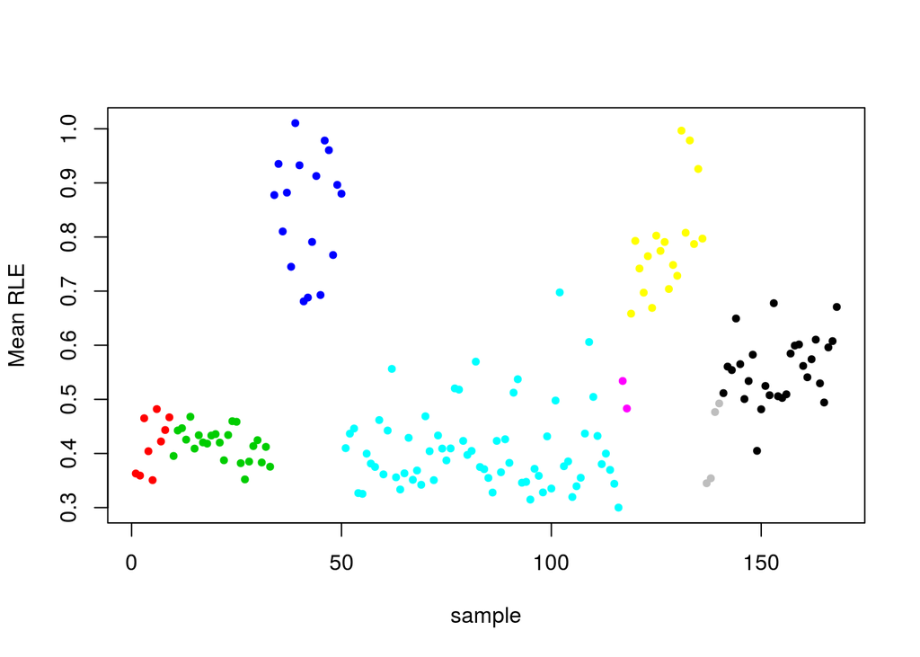

## 1.2 MDS

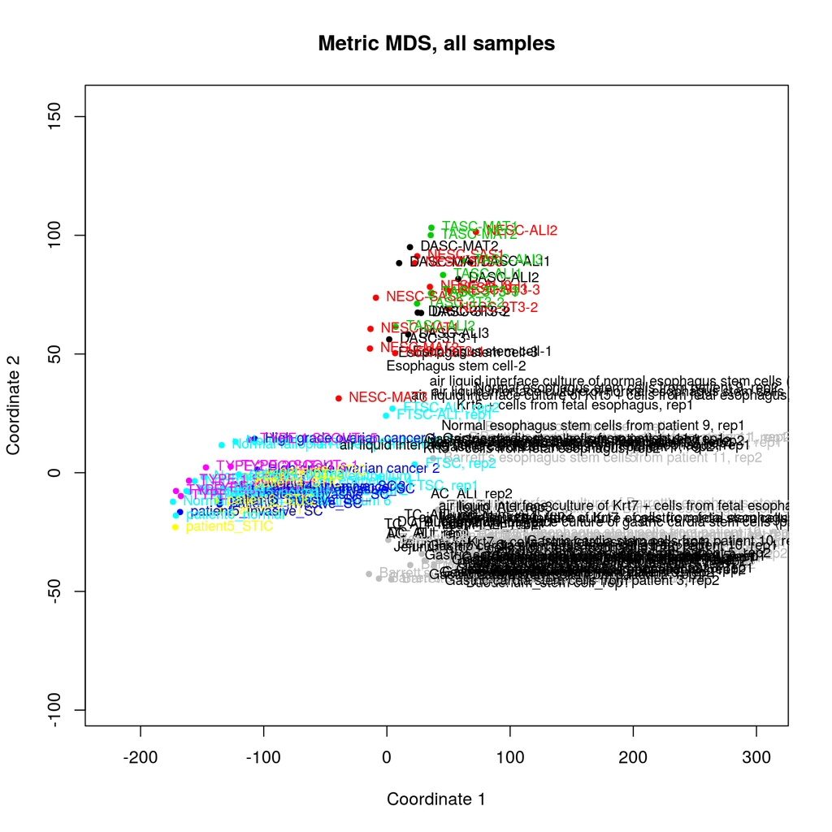

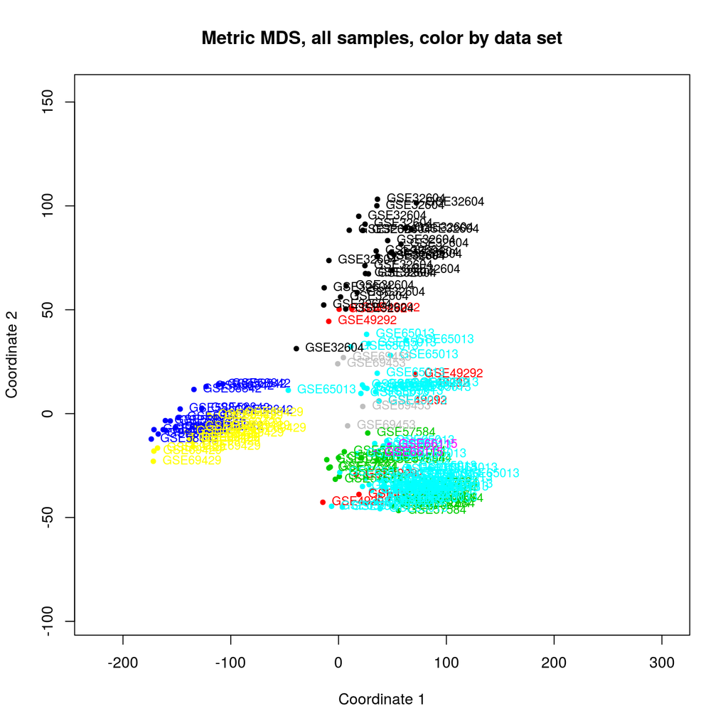

Conclusion from MDS: Strong clustering of datasets, with LCM-tissue datasets vs. in-vitro dominating Coordinate 1 and airways vs. intestinal data sets dominating Coordinate 2. We should exclude the LCM samples and do a separate analysis on airway cells.

## 1.3 Differential expression overview

### 1.3.1 Volcano plots

For each comparison, the distribution of the fold change (on a log2 scale) and adjusted p-value (on reverse logarithmical scale) is shown in a volcano plot. The red line denotes the FDR cutoff of 0.05.

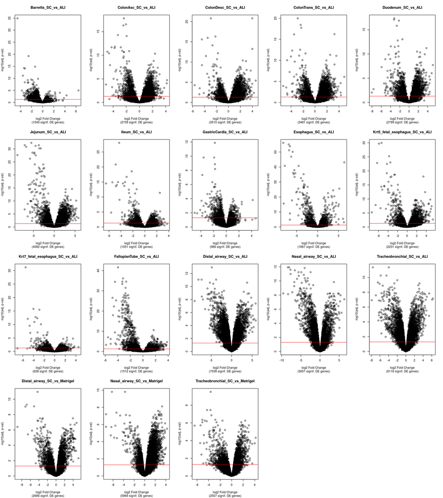

### 1.3.2 Overlaps between significantly expressed gene lists

The following table describes the overlap (intersection) of the list of differentially expressed genes between any two comparisons of a target condition to control.  
The Jaccard coefficient defines the ratio of the overlap size to the size of the union of both lists.

| Condition_1 | Condition_2 | Overlap of DE genes | Jaccard coefficient |
| --- | --- | --- | --- |
| Barretts_SC_vs_ALI | ColonAsc_SC_vs_ALI | 108 | 0.043 |
| Barretts_SC_vs_ALI | ColonDesc_SC_vs_ALI | 96 | 0.029 |
| Barretts_SC_vs_ALI | ColonTrans_SC_vs_ALI | 100 | 0.031 |
| Barretts_SC_vs_ALI | Duodenum_SC_vs_ALI | 148 | 0.057 |
| Barretts_SC_vs_ALI | Jejunum_SC_vs_ALI | 157 | 0.044 |
| Barretts_SC_vs_ALI | Ileum_SC_vs_ALI | 79 | 0.069 |
| Barretts_SC_vs_ALI | GastricCardia_SC_vs_ALI | 115 | 0.11 |
| Barretts_SC_vs_ALI | Esophagus_SC_vs_ALI | 80 | 0.039 |
| Barretts_SC_vs_ALI | Krt5_fetal_esophagus_SC_vs_ALI | 71 | 0.032 |
| Barretts_SC_vs_ALI | Krt7_fetal_esophagus_SC_vs_ALI | 72 | 0.084 |
| Barretts_SC_vs_ALI | FallopianTube_SC_vs_ALI | 94 | 0.051 |
| Barretts_SC_vs_ALI | Distal_airway_SC_vs_ALI | 201 | 0.036 |
| Barretts_SC_vs_ALI | Nasal_airway_SC_vs_ALI | 175 | 0.051 |
| Barretts_SC_vs_ALI | Tracheobronchial_SC_vs_ALI | 188 | 0.038 |
| Barretts_SC_vs_ALI | Distal_airway_SC_vs_Matrigel | 87 | 0.034 |
| Barretts_SC_vs_ALI | Nasal_airway_SC_vs_Matrigel | 132 | 0.025 |
| Barretts_SC_vs_ALI | Tracheobronchial_SC_vs_Matrigel | 94 | 0.038 |
| ColonAsc_SC_vs_ALI | ColonDesc_SC_vs_ALI | 1626 | 0.49 |
| ColonAsc_SC_vs_ALI | ColonTrans_SC_vs_ALI | 1708 | 0.54 |
| ColonAsc_SC_vs_ALI | Duodenum_SC_vs_ALI | 1101 | 0.34 |
| ColonAsc_SC_vs_ALI | Jejunum_SC_vs_ALI | 1445 | 0.37 |
| ColonAsc_SC_vs_ALI | Ileum_SC_vs_ALI | 480 | 0.2 |
| ColonAsc_SC_vs_ALI | GastricCardia_SC_vs_ALI | 161 | 0.061 |
| ColonAsc_SC_vs_ALI | Esophagus_SC_vs_ALI | 227 | 0.065 |
| ColonAsc_SC_vs_ALI | Krt5_fetal_esophagus_SC_vs_ALI | 519 | 0.16 |
| ColonAsc_SC_vs_ALI | Krt7_fetal_esophagus_SC_vs_ALI | 186 | 0.079 |
| ColonAsc_SC_vs_ALI | FallopianTube_SC_vs_ALI | 410 | 0.13 |
| ColonAsc_SC_vs_ALI | Distal_airway_SC_vs_ALI | 731 | 0.11 |
| ColonAsc_SC_vs_ALI | Nasal_airway_SC_vs_ALI | 413 | 0.086 |
| ColonAsc_SC_vs_ALI | Tracheobronchial_SC_vs_ALI | 652 | 0.11 |

[output cut: 123 more lines]

The heatmap below shows the overlap (intersection) of the list of differentially expressed genes between any two comparisons of a target condition to control. The diagonal shows the size of the individual list of differentially expressed genes for a comparison. Values are depicted on a log10 scale (i.e. 2 = overlap of 100 genes and so on).

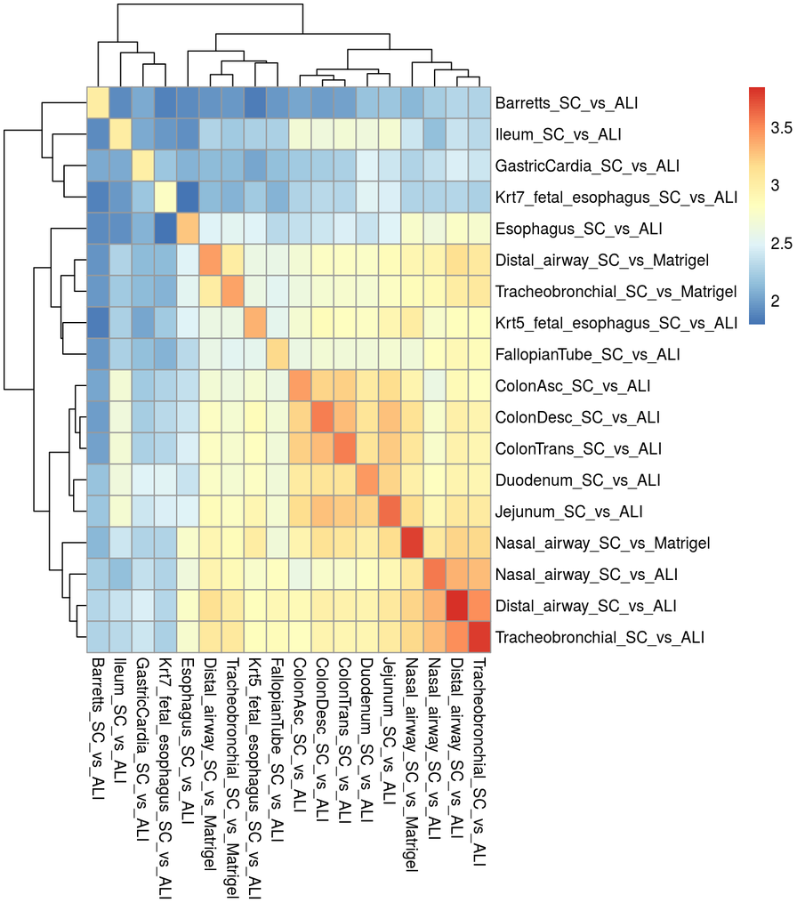

```r
pheatmap(log10(d_mat+1))
```

The following files have been written:

```
##                                                                                                          File name
## DGE.Barretts_SC_vs_ALI                           ./Results//Differential_expression_results_Barretts_SC_vs_ALI.txt
## DGE.ColonAsc_SC_vs_ALI                           ./Results//Differential_expression_results_ColonAsc_SC_vs_ALI.txt
## DGE.ColonDesc_SC_vs_ALI                         ./Results//Differential_expression_results_ColonDesc_SC_vs_ALI.txt
## DGE.ColonTrans_SC_vs_ALI                       ./Results//Differential_expression_results_ColonTrans_SC_vs_ALI.txt
## DGE.Duodenum_SC_vs_ALI                           ./Results//Differential_expression_results_Duodenum_SC_vs_ALI.txt
## DGE.Jejunum_SC_vs_ALI                             ./Results//Differential_expression_results_Jejunum_SC_vs_ALI.txt
## DGE.Ileum_SC_vs_ALI                                 ./Results//Differential_expression_results_Ileum_SC_vs_ALI.txt
## DGE.GastricCardia_SC_vs_ALI                 ./Results//Differential_expression_results_GastricCardia_SC_vs_ALI.txt
## DGE.Esophagus_SC_vs_ALI                         ./Results//Differential_expression_results_Esophagus_SC_vs_ALI.txt
## DGE.Krt5_fetal_esophagus_SC_vs_ALI   ./Results//Differential_expression_results_Krt5_fetal_esophagus_SC_vs_ALI.txt
## DGE.Krt7_fetal_esophagus_SC_vs_ALI   ./Results//Differential_expression_results_Krt7_fetal_esophagus_SC_vs_ALI.txt
## DGE.FallopianTube_SC_vs_ALI                 ./Results//Differential_expression_results_FallopianTube_SC_vs_ALI.txt
## DGE.Distal_airway_SC_vs_ALI                 ./Results//Differential_expression_results_Distal_airway_SC_vs_ALI.txt
## DGE.Nasal_airway_SC_vs_ALI                   ./Results//Differential_expression_results_Nasal_airway_SC_vs_ALI.txt
## DGE.Tracheobronchial_SC_vs_ALI           ./Results//Differential_expression_results_Tracheobronchial_SC_vs_ALI.txt
## DGE.Distal_airway_SC_vs_Matrigel       ./Results//Differential_expression_results_Distal_airway_SC_vs_Matrigel.txt
## DGE.Nasal_airway_SC_vs_Matrigel         ./Results//Differential_expression_results_Nasal_airway_SC_vs_Matrigel.txt
## DGE.Tracheobronchial_SC_vs_Matrigel ./Results//Differential_expression_results_Tracheobronchial_SC_vs_Matrigel.txt
## DGE.comparison                                                                ./Results//DE_results_comparison.txt
## Normalized.expression.values                                             ./Results//Normalized_expression_data.txt
##                                                 Format
## DGE.Barretts_SC_vs_ALI              Tab separated text
## DGE.ColonAsc_SC_vs_ALI              Tab separated text
## DGE.ColonDesc_SC_vs_ALI             Tab separated text
## DGE.ColonTrans_SC_vs_ALI            Tab separated text
## DGE.Duodenum_SC_vs_ALI              Tab separated text
## DGE.Jejunum_SC_vs_ALI               Tab separated text
## DGE.Ileum_SC_vs_ALI                 Tab separated text
## DGE.GastricCardia_SC_vs_ALI         Tab separated text
## DGE.Esophagus_SC_vs_ALI             Tab separated text
## DGE.Krt5_fetal_esophagus_SC_vs_ALI  Tab separated text
## DGE.Krt7_fetal_esophagus_SC_vs_ALI  Tab separated text
## DGE.FallopianTube_SC_vs_ALI         Tab separated text
## DGE.Distal_airway_SC_vs_ALI         Tab separated text
## DGE.Nasal_airway_SC_vs_ALI          Tab separated text
## DGE.Tracheobronchial_SC_vs_ALI      Tab separated text
## DGE.Distal_airway_SC_vs_Matrigel    Tab separated text
## DGE.Nasal_airway_SC_vs_Matrigel     Tab separated text
## DGE.Tracheobronchial_SC_vs_Matrigel Tab separated text
## DGE.comparison                      Tab separated text
## Normalized.expression.values        Tab separated text
```